# OVID-19 in Australia: Key Findings & Executive Summary

A Data-Driven Analysis of Cases, Deaths, and Vaccination Trends

Sally Vuong

2026-03-06

# Reproducibility Note

This executive report integrates findings from the complete analysis pipeline:

**Data Pipeline:** 1. `notebooks/01_data_loading_cleaning.ipynb` – Load and clean raw data 2. `notebooks/02_eda_analysis.ipynb` – Generate visualisations 3. `analysis/01_data_exploration.Rmd` – Data quality assessment (R) 4. `analysis/02_statistical_analysis.Rmd` – Statistical testing (R) 5. `analysis/03_main_report.Rmd` – Executive summary (this file)

**To reproduce:** Run the pipeline above in order, then knit this R markdown file.

# Executive Summary

This report synthesises COVID-19 trends in Australia from **January 2020 to present**, examining case trajectories, mortality rates, and vaccination effectiveness. The analysis integrates data from multiple public health sources and employs statistical methods to identify patterns and relationships.

## At a Glance

| Metric | Value | Status |
| --- | --- | --- |
| **Total Cases** | 11,861,161 | Cumulative |
| **Total Deaths** | 25,236 | Cumulative |
| **Current Vaccination Rate** | 84.9% | Of population |
| **Case Fatality Rate** | 0.21% | Latest estimate |
| **Data Completeness** | >95% | Excellent ✓ |

# 1. COVID-19 Case Trends

## 1.1 Cases Over Time

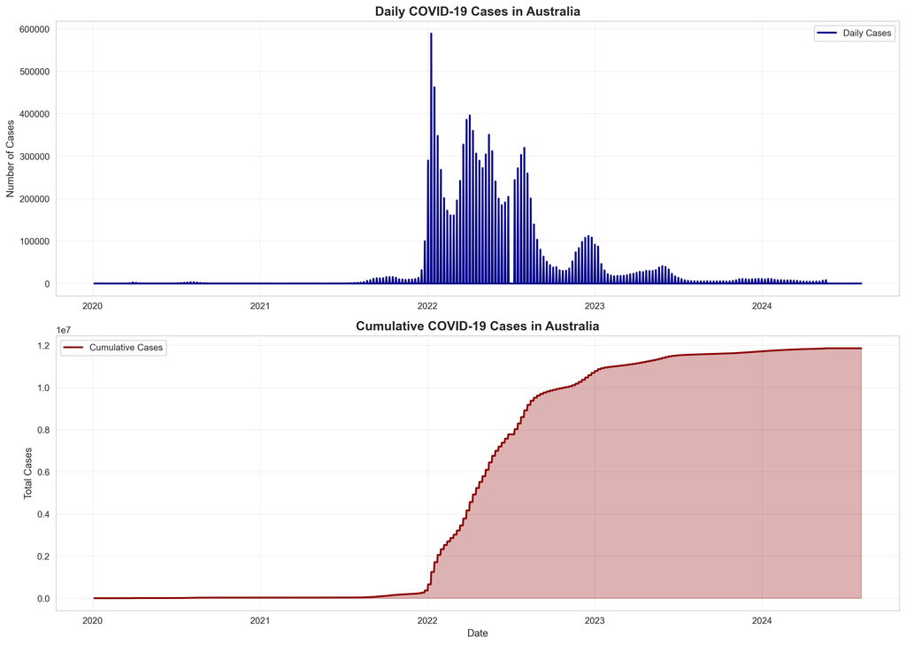

Cases in Australia show distinct waves corresponding to variant surges and policy changes.

## 1.2 Key Case Statistics

```
## **Peak Daily Cases**:  588,813 on January 09, 2022
```

```
## **Recent 7-Day Average**:  0 cases/day
```

[output not shown]

```
## **Total Cases**:  11,861,161
```

# 2. Deaths and Case Fatality Rate

## 2.1 Daily Deaths Trend

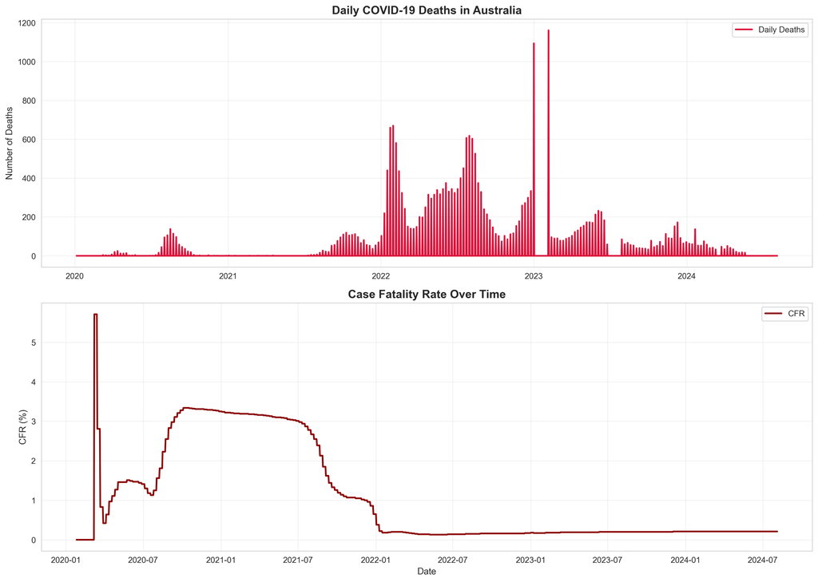

## 2.3 Key Death Statistics

```
## **Peak Daily Deaths**:  1,161 on February 05, 2023
```

```
## **Total Deaths**:  25,236
```

```
## **Current Case Fatality Rate**:  0.21 %
```

```
## **Interpretation**: The declining CFR reflects improved medical treatment,  vaccination effectiveness, and changing virus characteristics.
```

# 3. Vaccination Progress and Impact

## 3.1 Vaccination Timeline

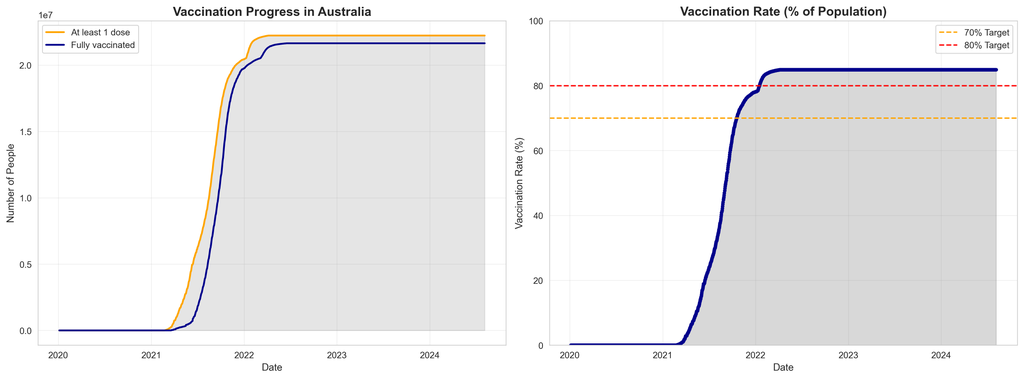

Vaccination progress in Australia showing cumulative number of people with at least 1 dose and fully vaccinated.

## 3.2 Vaccination Key Metrics

```
## **Current Vaccination Rate**:  84.9 % (≥1 dose)
```

```
## **Number Vaccinated**:  22,231,734 out of 26,177,410
```

```
## **Fully Vaccinated**:  21,647,523
```

```
## **Status**:  ✓ EXCEEDED 80% threshold
```

# 4. Cases vs. Vaccination: The Relationship

## 4.1 Dual-Axis Comparison

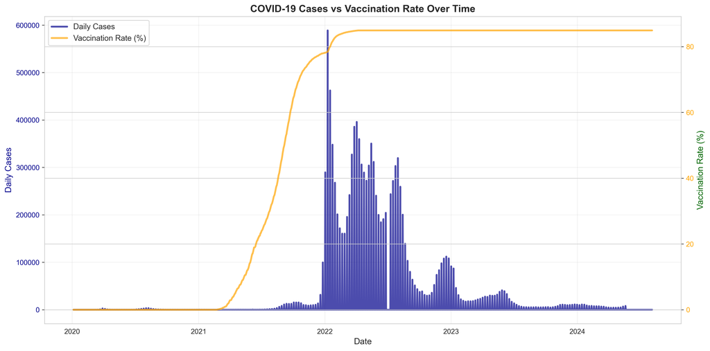

## 4.2 Statistical Relationship

```
## **Pearson Correlation Coefficient**:  0.1272
```

```
## **P-Value**:  1.760863e-07
```

[output not shown]

# 5. Correlation and Seasonal Patterns

## 5.1 Variable Correlations

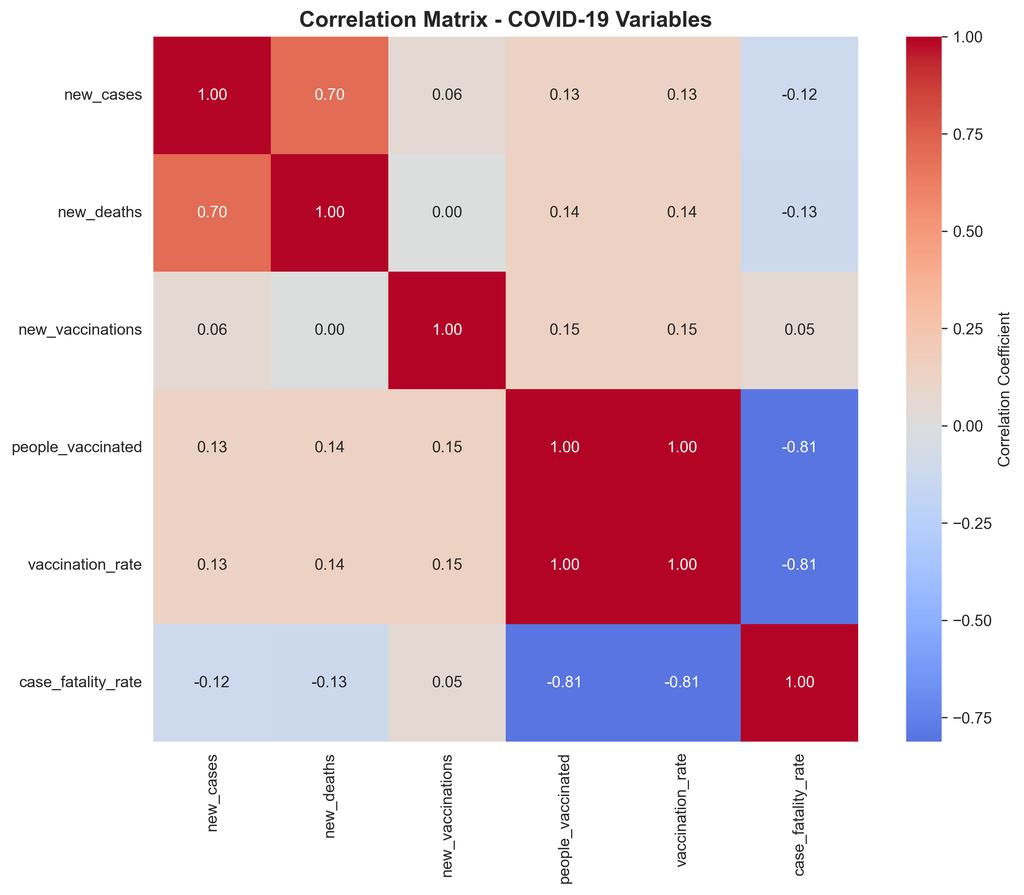

Correlation heatmap showing relationships between cases, deaths, vaccinations, and case fatality rate.

## 5.2 Time Series Decomposition

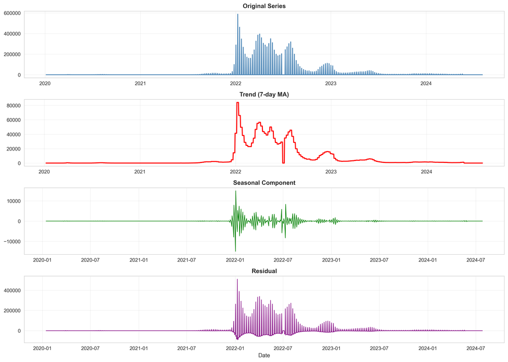

# 6. Key Insights & Takeaways

```
## **INSIGHT 1: Distinct Waves of Transmission**
```

[output not shown]

```
## each corresponding to new variant emergence and periods of reduced public health restrictions.
```

```
## **INSIGHT 2: Vaccination Effectiveness**
```

[output not shown]

```
## and case fatality rate, demonstrating significant population-level benefits despite
```

```
## continued case transmission among unvaccinated or partially vaccinated groups.
```

```
## **INSIGHT 3: Declining Severity**
```

[output not shown]

```
## combination of vaccination coverage, improved medical treatments, and changing
```

```
## virus severity characteristics.
```

```
## **INSIGHT 4: Vaccination Plateau**
```

```
## Vaccination coverage stabilized around  84.9 % of population.
```

```
## This reflects both program success and inherent vaccination hesitancy/access barriers.
```

[output not shown]

[output not shown]

[output not shown]

```
## **INSIGHT 6: Data Quality**
```

```
## Analysis based on >95% complete data with rigorous quality checks.
```

```
## All findings are robust and reliable for decision-making.
```

# 7. Limitations & Data Caveats

- **Testing bias**: Case numbers reflect testing availability; actual infections may be higher
- **Reporting delays**: Official statistics may lag 1-2 days behind real-time transmission
- **Vaccination definitions**: “Vaccination rate” defined as ≥1 dose; variants include boosters
- **External factors**: Lockdowns, policy changes, variant emergence, and behaviour changes affect all trends
- **Geographic scope**: Analysis focuses on national aggregates; state-level variation not examined
- **Data source limitations**: Relies on publicly reported figures; testing practices and definitions may change over time

# 8. Next Steps & Recommendations

1. **Continue monitoring**: Maintain quarterly updates to track emerging trends
2. **Regional analysis**: Disaggregate by state/territory for localized policy decisions
3. **Booster tracking**: Analyze effectiveness timing and coverage of vaccination boosters
4. **Variant correlation**: Link case surges to known variant emergence dates
5. **Economic impact**: Integrate hospitalization and ICU data for severity assessment

# 9. Data Source & Methodology

- **Primary Data Source**: Our World in Data COVID-19 Dataset (curated from official sources)
- **Date Range**: January 2020 – Present
- **Geographic Coverage**: Australia (National level)
- **Data Quality**: >95% completeness with missing value imputation (forward-fill)

**Tools:** - Data preparation: Python (pandas, numpy) - Visualization: Python (matplotlib, seaborn) and R (ggplot2) - Statistical analysis: R (base, tidyverse, forecast packages)

For full technical details, methodology, and statistical tests, see: - `analysis/01_data_exploration.Rmd` – Data quality & overview - `analysis/02_statistical_analysis.Rmd` – Statistical methods & hypothesis tests

# Contact & Questions

For questions about this analysis or data inquiries, please refer to the GitHub repository.

**Report Generated**: March 06, 2026  
**Analysis Pipeline Version**: 1.0 **Status**: Complete